# GeRgraphy

16 March, 2016

## GIS

### Geographic Information Systems

## GIS

### Geographic Information Systems

- incorporating
- storing
- manipulating
- analyzing
- displaying…

## Spatial Data

## What is spatial data?

Nonspatial data **has no** location information

```r
nonspatial = data.frame(
  id=c(1,2,3,4),
  data=rnorm(4)
)
print(nonspatial)
```

```
##   id        data
## 1  1  0.16159700
## 2  2  0.78714960
## 3  3  0.14879109
## 4  4 -0.06193099
```

## What is spatial data?

Spatial data **has** location information

The simplest spatial data are points on a map

```r
spatial = data.frame(
  id=c(1,2,3,4),
  data=rnorm(4),
  x=runif(4,-180,180),
  y=runif(4,-90,90)
)
print(spatial)
```

```
##   id       data          x          y
## 1  1  0.5287954 -165.07741  37.290336
## 2  2  0.9985252  169.41178  -4.529977
## 3  3  0.1259651  -95.50861 -42.701940
## 4  4 -0.3418290   66.72712 -41.519713
```

## What is spatial data?

Which we can convert to explicitly spatial data using the `sp` package. Most GIS packages in R store data as `sp` classes.

```r
library(sp)
```

## What is spatial data?

The `sp` package has a method called `coordinates` that converts points to an `sp` class.

```r
coordinates(spatial) = ~ x + y
class(spatial)
```

```
## [1] "SpatialPointsDataFrame"
## attr(,"package")
## [1] "sp"
```

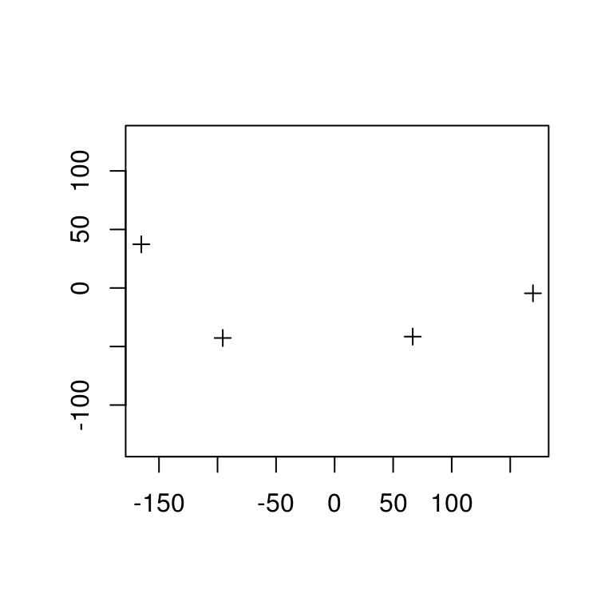

```r
plot(spatial, axes=T)
```

## What is spatial data?

Spatial data also needs a reference system or **"projection"** that allows us to represent spatial features on a map. Projections can be thought of as simply a coordinate system with an origin that is relative to a known point in space.

This is a whole field of mathematically intensive study termed "geodesy"

Much of the field of geodesy is jam-packed in the `rgdal` and `sp` packages, which use the PROJ.4 library for projections and transformations.

```r
##While automatically load sp for us too
library(rgdal)
```

Wonderful document on CRS in R [here](https://www.nceas.ucsb.edu/~frazier/RSpatialGuides/OverviewCoordinateReferenceSystems.pdf)

## What is spatial data?

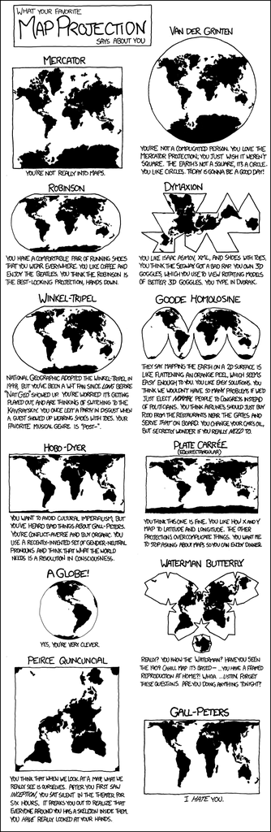

## What is spatial data?

`rgdal` includes a comprehensive list of projections that are typically represented as a **string of parameters** according to the PROJ.4 specifications. The simplest is a latitude/longitude system denoted as

`"+proj=longlat"`

To define the projection for `spatial`, we write to its `proj4string` slot:

```r
proj4string(spatial) = "+proj=longlat"
```

Projections are a necessary evil for GIS users (to be continued)

## What is spatial data?

With a projection associated with our spatial data, we can now relate it to other spatial data. In other words, let's make a map!

```r
library(leaflet)
```

```r
m = leaflet(data=spatial) %>%
  addTiles() %>%
  addMarkers()
m
```

## What is spatial data?

[interactive chart not shown]

## Spatial data types

## Spatial data types

### Two main types: vector and raster

Vector = Polygons  
Raster = Grid  
Vector = Discrete  
Raster = Continuous  
Vector = Illustrator/Inkscape  
Raster = Photoshop/GIMP

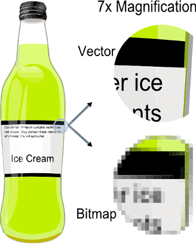

## Spatial data types

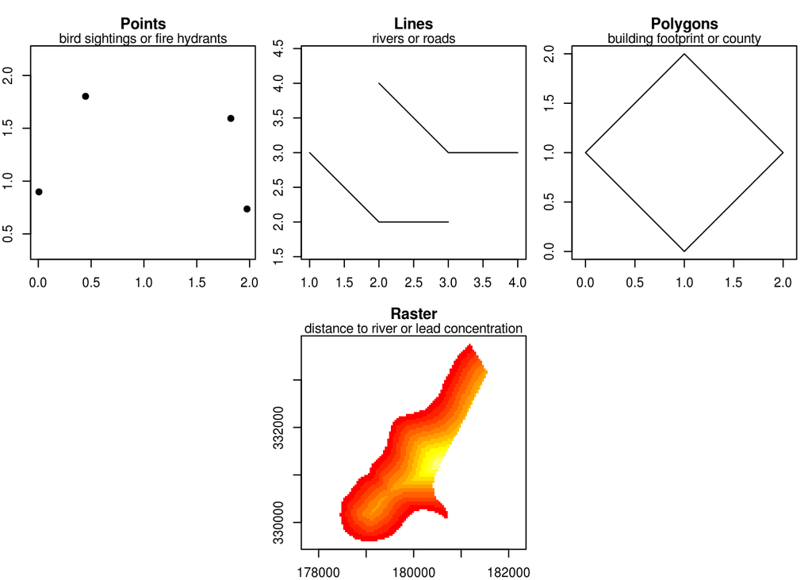

## Vector Data

## Vector Data Intro

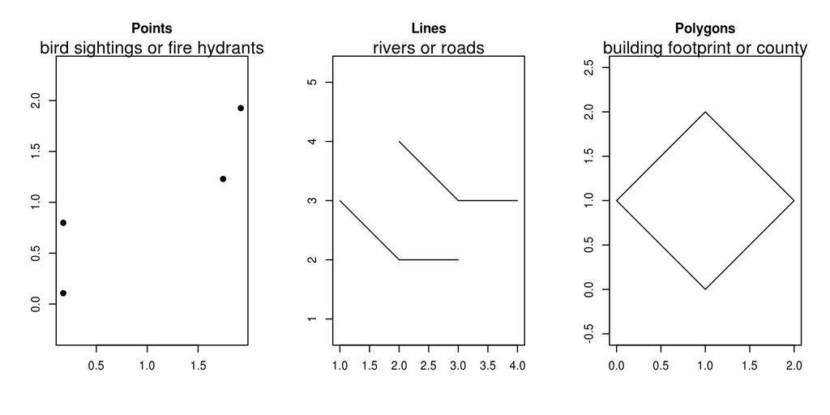

## Vector Data Intro

Whether, points, lines or polygons, *comprised of coordinate pairs*

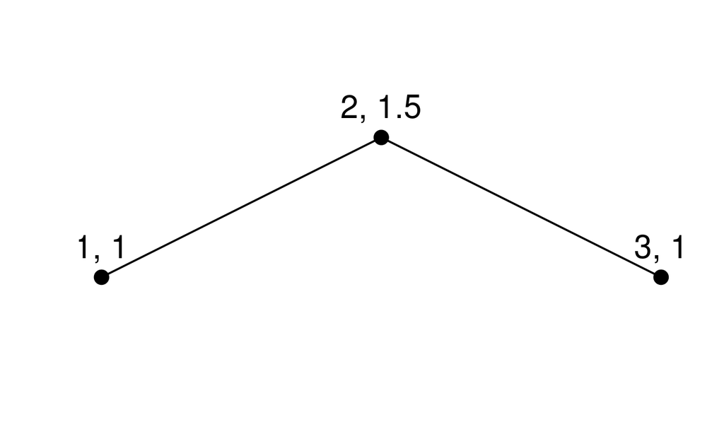

## Vector Data Intro

Think like a table, each row (observation) is referred to as a *feature*.

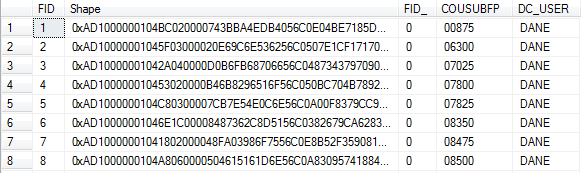

The other data is often referred to as the *attribute table* and or as *attribute data*.

Each row is one observation (one feature), this becomes important later, are we referring to individual features or to the entire geometry.

## Vector Data Basics

Data Input/Output

```r
library(rgdal)
soils = readOGR(
    dsn="data",
    layer="soilsData")
writeOGR(
    soils,
    "data",
    "soilsData_out",
    driver="ESRI Shapefile"
)
```

## Vector Data Basics

Other ways of creating of spatial data from list of coordinates:

```r
wells = read.delim("./data/WellLocations.tsv")
class(wells); head(wells)
```

```
## [1] "data.frame"
```

```
##           x        y pts.data.id
## 1 -90.05145 43.10047           1
## 2 -90.05553 43.10470           2
## 3 -90.07305 43.09013           3
## 4 -90.04716 43.08454           4
## 5 -90.07198 43.08850           5
## 6 -90.06599 43.09197           6
```

```r
coordinates(wells) <- ~ x + y
class(wells)
```

```
## [1] "SpatialPointsDataFrame"
## attr(,"package")
## [1] "sp"
```

## Vector Data Basics

Helper functions:

```r
class(soils)
```

```
## [1] "SpatialPolygonsDataFrame"
## attr(,"package")
## [1] "sp"
```

```r
slotNames(soils)
```

```
## [1] "data"        "polygons"    "plotOrder"   "bbox"        "proj4string"
```

```r
length(soils)
```

```
## [1] 71
```

## Vector Data Basics

Accessing attribute data

```r
str(soils@data[,1:10])
```

```
## 'data.frame':    71 obs. of  10 variables:
##  $ mukey  : Factor w/ 25 levels "2774742","2774772",..: 12 19 12 6 9 5 7 24 25 13 ...
##  $ muarcrs: Factor w/ 71 levels "0.40538405","0.90105194",..: 29 59 67 17 8 25 18 5 14 22 ...
##  $ Sand1  : num  21.5 11 21.5 12 29.5 ...
##  $ Sand2  : num  35.29 8.34 35.29 9.02 38.22 ...
##  $ Sand3  : num  45.09 7.56 45.09 16.59 64.52 ...
##  $ Sand4  : num  48.6 30.6 48.6 36.7 33.2 ...
##  $ Sand5  : num  0 31.1 0 27.1 57.2 ...
##  $ Silt1  : num  45.8 65.2 45.8 68.7 54.5 ...
##  $ Silt2  : num  37.3 64.9 37.3 60.3 43.5 ...
##  $ Silt3  : num  36.7 64.1 36.7 34 21.1 ...
```

## Vector Data Basics

The geometry stored in the polygons slot

```r
str(soils@polygons[1])
```

```
## List of 1
##  $ :Formal class 'Polygons' [package "sp"] with 5 slots
##   .. ..@ Polygons :List of 1
##   .. .. ..$ :Formal class 'Polygon' [package "sp"] with 5 slots
##   .. .. .. .. ..@ labpt  : num [1:2] 514199 291168
##   .. .. .. .. ..@ area   : num 10776
##   .. .. .. .. ..@ hole   : logi FALSE
##   .. .. .. .. ..@ ringDir: int 1
##   .. .. .. .. ..@ coords : num [1:21, 1:2] 514211 514206 514195 514178 514180 ...
##   .. ..@ plotOrder: int 1
##   .. ..@ labpt    : num [1:2] 514199 291168
##   .. ..@ ID       : chr "0"
##   .. ..@ area     : num 10776
```

## Vector Data Basics

A number of common functions have methods for spatial data

```r
silty = subset(soils, Silt1 > 70)
paste("There are", length(soils), "soil features total;")
```

```
## [1] "There are 71 soil features total;"
```

```r
paste(length(silty), "with a silt percentage over 70")
```

```
## [1] "10 with a silt percentage over 70"
```

## Vector data basics

Making simple maps is quite easy

```r
par(mfrow=c(1,2), bg=NA)
plot(
    soils,
    main="Soils Polygons",
    col=rainbow(5))
plot(
    wells,
    main="Well Data",
    col='red'
)
```

## Vector data basics

[figure not shown]

## Coordinate Reference Systems

### A (Very) Brief Break

A coordinate reference system (CRS) defines the surface of the world. If they don't match, errors and issues can arise

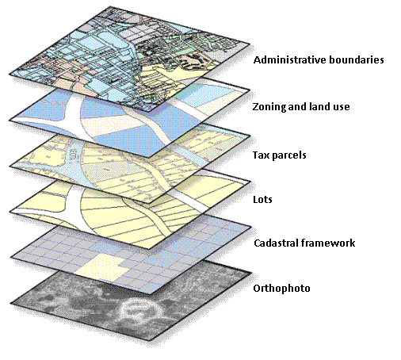

## Coordinate Reference Systems

### A (Very) Brief Break

To illustrate issues, where are the wells in relation to the soil?

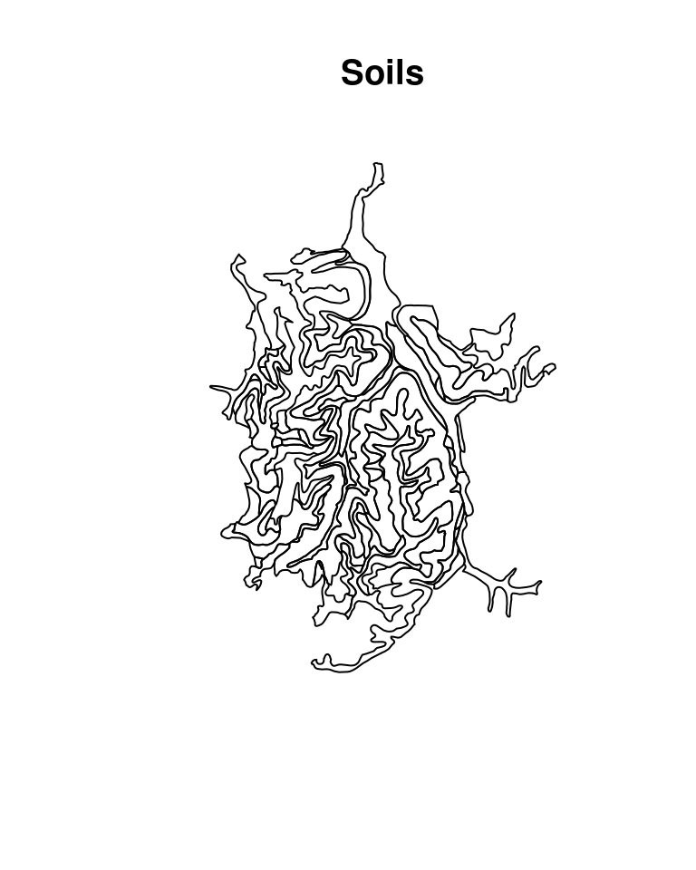

```r
soils = readOGR(
    dsn="data",
    layer="soilsData")
plot(
    soils,
    main="Soils"
)
plot(
    wells,
    add=T
)
```

## Coordinate Reference Systems

### A (Very) Brief Break

```r
print(wells@proj4string)
```

```
## CRS arguments: NA
```

```r
print(soils@proj4string)
```

```
## CRS arguments:
##  +proj=tmerc +lat_0=0 +lon_0=-90 +k=0.9996 +x_0=520000
## +y_0=-4480000 +datum=NAD83 +units=m +no_defs +ellps=GRS80
## +towgs84=0,0,0
```

```r
coordinates(soils)[c(1,72)]
```

```
## [1] 514198.6 291168.3
```

```r
coordinates(wells)[c(1,16)]
```

```
## [1] -90.05145  43.10047
```

## Coordinate Reference Systems

### A (Very) Brief Break

Solution: *define* the CRS then *project* the points to CRS of the soils data

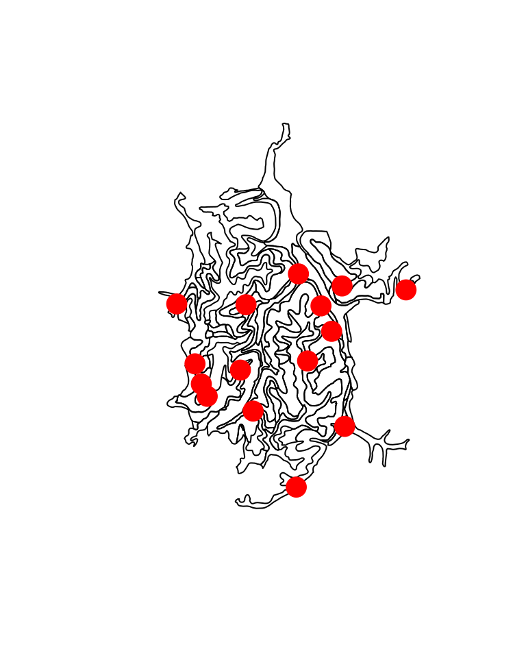

```r
wells@proj4string = CRS(
"+proj=longlat +ellps=WGS84 +datum=WGS84 +no_defs")
wells = spTransform(
    wells,
    soils@proj4string)
plot(soils)
plot(
    wells,
    add=T,
    cex=2,
    col='red',
    pch=19
)
```

## Vector Data Geometry Relationships

How do two shapes relate? Sometimes we want to have a yes/no true/false answer to how two geometries relate. *Spatial Predicates* is the term for this

All contained in the `rgeos` package. Here we see `gIntersects` used on these two polygons. `gEquals`, `gTouches`, `gCrosses`, `gContains` and others.

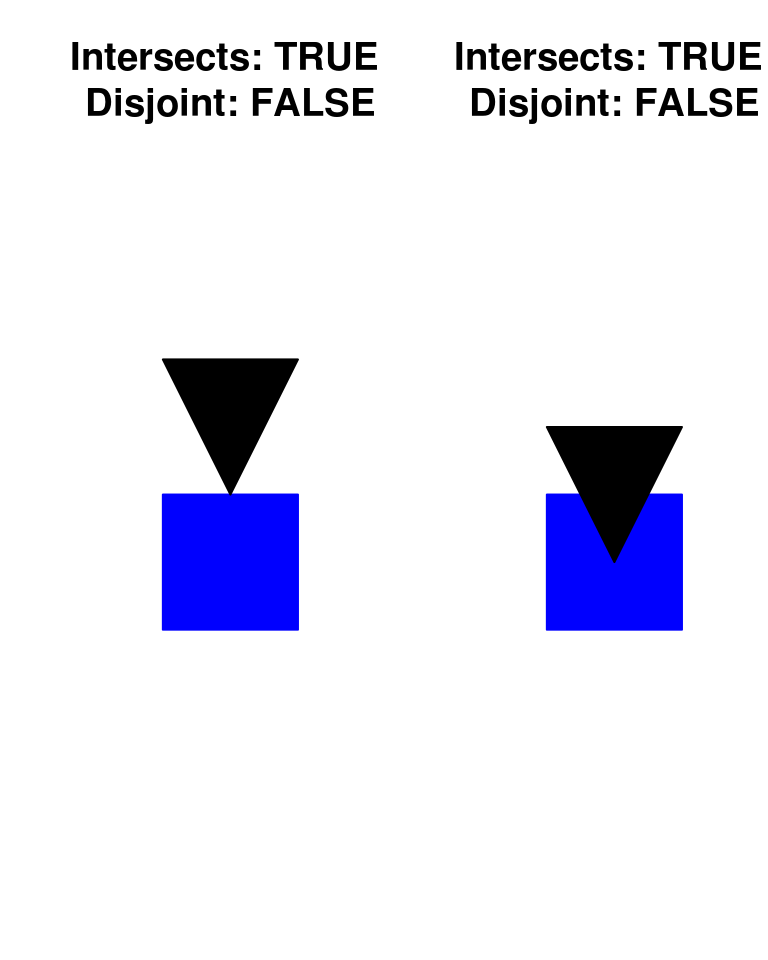

## Vector Data Example

```r
gIntersects(soils, wells)
```

```
## [1] TRUE
```

```r
head(gIntersects(wells, soils, byid=T, returnDense=T))
```

```
##       1     2     3     4     5     6     7     8     9    10    11    12
## 0 FALSE FALSE FALSE FALSE FALSE FALSE FALSE FALSE FALSE FALSE FALSE FALSE
## 1 FALSE FALSE FALSE FALSE FALSE FALSE FALSE FALSE FALSE FALSE FALSE FALSE
## 2 FALSE FALSE FALSE FALSE FALSE FALSE FALSE FALSE FALSE FALSE FALSE FALSE
## 3 FALSE FALSE FALSE FALSE FALSE FALSE FALSE FALSE FALSE FALSE FALSE FALSE
## 4 FALSE FALSE FALSE FALSE FALSE FALSE FALSE FALSE FALSE FALSE FALSE FALSE
## 5 FALSE FALSE FALSE FALSE FALSE FALSE FALSE FALSE FALSE FALSE FALSE FALSE
##      13    14    15
## 0 FALSE FALSE FALSE
## 1 FALSE FALSE FALSE
## 2 FALSE FALSE FALSE
## 3 FALSE FALSE FALSE
## 4 FALSE FALSE FALSE
## 5 FALSE FALSE FALSE
```

```r
gIntersects(wells, soils, byid=T, returnDense=F)[1:2]
```

```
## $`1`
## [1] 66
##
## $`2`
## [1] 36
```

## Vector Data Example

```r
gIntersects(wells, soils, byid=T, returnDense=F)[1:4]
```

```
## $`1`
## [1] 66
##
## $`2`
## [1] 36
##
## $`3`
## [1] 22
##
## $`4`
## [1] 29
```

## Vector Data Example

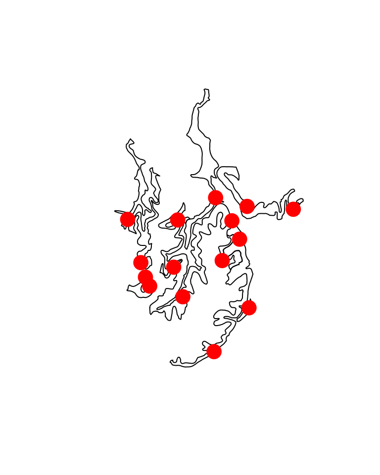

```r
indxs <- gIntersects(

    wells,
    soils,
    byid=T,
    returnDense=F) %>%
    unlist %>%
    unique

soils_with_wells = soils[indxs,]
plot(
    soils_with_wells
)
plot(
    wells,
    add=T,
    cex=2,
    pch=19,
    col='red'
)
```

## Vector Data Example

Extract soils data to our point data…

```r
soilsDat = over(wells, soils)
class(soilsDat)
```

```
## [1] "data.frame"
```

```r
soilsDat$id = 1:15

wells = merge(wells, soilsDat, by.x="pts.data.id", by.y="id")
head(wells@data)
```

```
##   pts.data.id   mukey      muarcrs    Sand1     Sand2    Sand3    Sand4
## 1           1 2806652 405.22965906 35.87900 32.747667 69.83400 73.27298
## 2           2 2806642 127.65139889 14.10700 14.001433 13.06847 14.28767
## 3           3 2774772  23.43535446 10.51290  9.529000 10.50538 24.74279
## 4           4 2774821   9.99030648 13.44400 11.495200  9.31480 30.69747
## 5           5 2774777   4.35597440 12.03429  9.015357 16.59286 36.73413
## 6           6 2774798   8.69344646 21.47179 35.293641 45.09015 48.59615
##      Sand5    Silt1    Silt2    Silt3    Silt4    Silt5    Clay1    Clay2
## 1 73.07354 49.00485 40.71233 15.42715 13.57983 14.06340 15.11615 26.54000
## 2 15.86000 71.64800 71.62823 70.58203 68.64867 69.06100 14.24500 14.37033
## 3 30.45305 70.65485 65.64850 65.46994 35.22879 54.23537 18.83225 24.82250
## 4 48.58000 68.94600 67.97213 66.78053 47.81453 35.96000 17.61000 20.53267
## 5 27.11190 68.71821 60.28321 34.02286 39.86052 41.12143 19.24750 30.70143
## 6  0.00000 45.78205 37.27431 36.66754 28.13462  0.00000 32.74615 27.43205
##      Clay3    Clay4    Clay5       OM1       OM2       OM3       OM4
## 1 14.73885 13.14719 12.86306 1.7208333 0.3348077 0.2575000 0.2519231
## 2 16.34950 17.06367 15.07900 2.1704167 1.9599167 2.7409167 1.8906667
## 3 24.02468 40.02842 15.31158 0.9820000 0.2550000 0.2550395 0.2535526
## 4 23.90467 21.48800 15.46000 2.7300000 1.6890000 0.5740000 0.4036667
## 5 49.38429 23.40536 31.76667 1.2584821 0.2544643 0.2500000 0.2500000
## 6 18.24231 13.01282  0.00000 0.8837179 0.2500000 0.2500000 0.2243590
##      OM5 Depth1 Depth2 Depth3 Depth4 Depth5
## 1 0.2500     39     40     40     40     40
## 2 0.2575     30     31     30     31     31
## 3 0.2500     40     40     41     40     41
## 4 0.2600     30     31     31     31     31
## 5 0.2500     28     29     28     29     29
## 6 0.0000     39     40     40     40     40
```

## Vector Data Example

Perhaps we want to expand our our of concern

```r
## buffer of 50 meters (because of our projection) around each well
wells_area = gBuffer(wells, byid = T, width = 50)
class(wells_area)
```

```
## [1] "SpatialPolygonsDataFrame"
## attr(,"package")
## [1] "sp"
```

```r
soils@data = subset(soils@data, select = c("Sand1", "Silt1"))
head(over(wells_area, soils, fn = mean))
```

```
##      Sand1    Silt1
## 1 24.84412 58.12692
## 2 12.96008 68.01767
## 3 11.08520 69.97385
## 4 13.62663 68.09750
## 5 12.03429 68.71821
## 6 16.56465 57.53745
```

## Vector Data

Another kind of relationship functions return the geometry (versus returning booleans) How do we get the overlapping area?

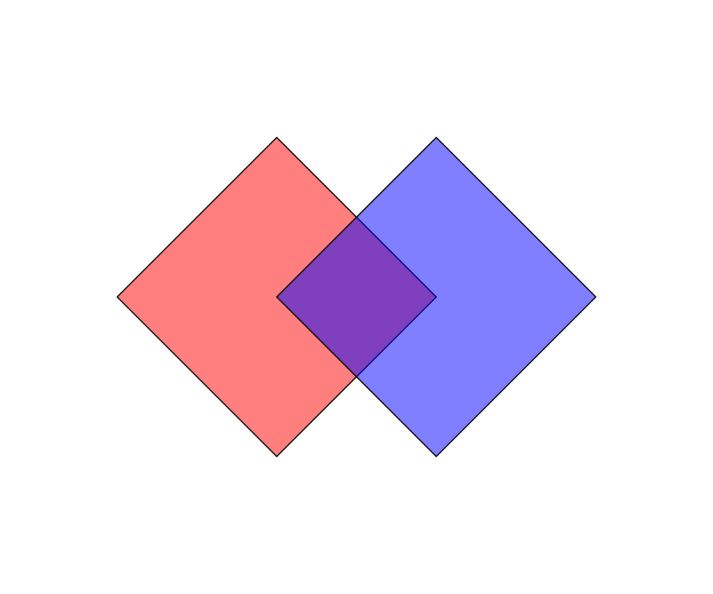

## Vector Data

We use the `gIntersection` function, this returns that area to us `xyinter = gIntersection(x, y)`. Other functions like `gDifference`, `gUnion`, or `gSymdifference` also return geometry.

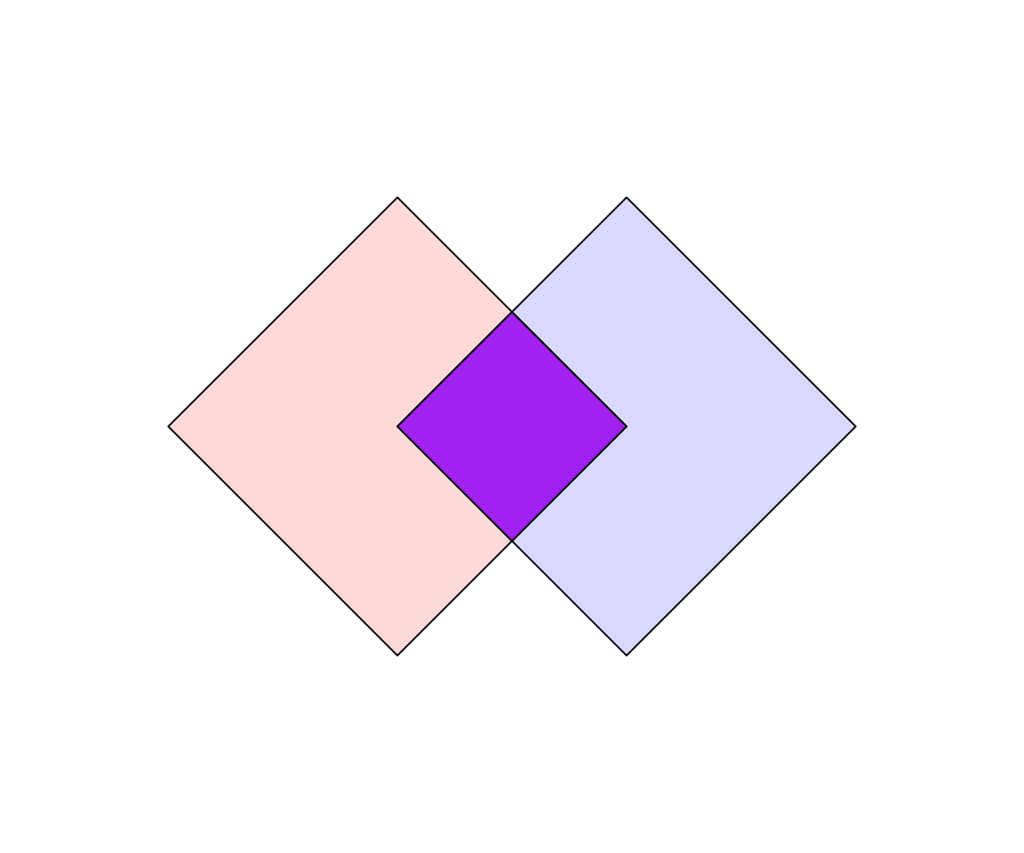

## Vector Data

Grab data within a certain range of the middle? Note how this returns geometry

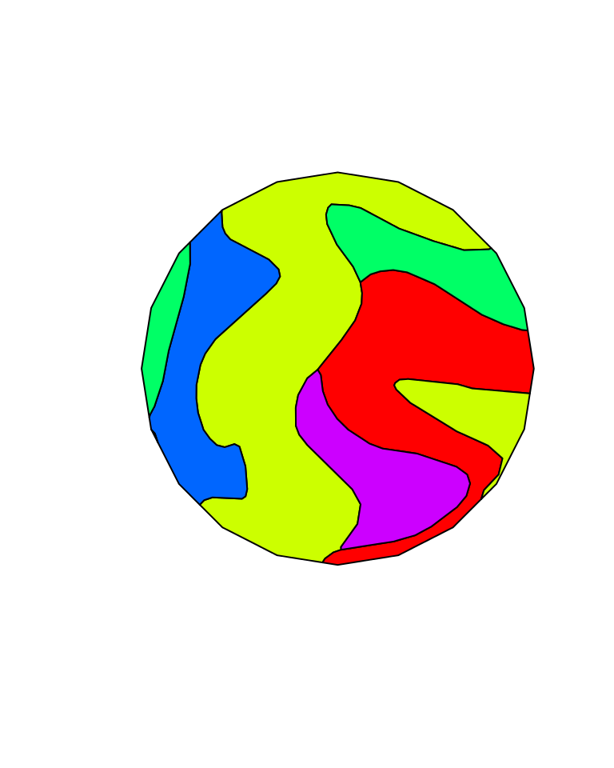

```r
cent = gCentroid(soils)
bff = gBuffer(cent, width = 250)
int = gIntersection(soils, bff, byid = T)
plot(int, col = rainbow(5))
```

## Vector Data Plotting

Scenario tasked with:

- Create map of percent Democratic votes by ward
- Also display percent turnout

```r
wards = readOGR("data", "WardData")
```

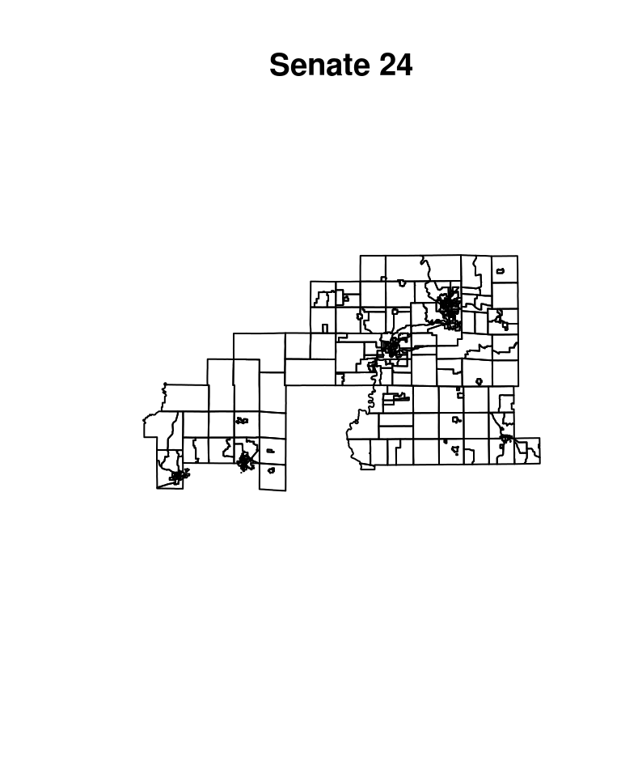

## Vector Data Plotting

```r
options(stringsAsFactors=F)
source("./misc_scripts/function_proper_legend.r")
library(rgdal)
library(rgeos)
library(foreign)
library(classInt)
library(RColorBrewer)
library(scales)

wards@data$SEN_PERC_DEM = with(wards@data, SEN_DEM/SEN_TOT)
wards@data$SEN_PERC_TURN = with(wards@data, SEN_TOT/PERSONS1)

wards_centroids = gCentroid(wards, byid=T)
wards_centroids = SpatialPointsDataFrame(
    gCentroid(wards, byid=T),
    over(wards_centroids, wards)
)
```

## Vector Data Plotting

```r
## defining number of classes
num_classes = 6
## the color palette
pal = brewer.pal(num_classes, "RdBu")
## the class intervals to use for the colors
class_ints = classIntervals(
    wards@data$SEN_PERC_DEM,
    num_classes,
    style="quantile")
## grab the colors for plotting
colrs = findColours(class_ints, pal)
```

## Vector Data Plotting

```r
## Custom legend formatting
source("./misc_scripts/function_proper_legend.r")
legtxt = properLegend(colrs, 2)
plot(wards,
     col=colrs,
     main="Senate 24",
     border=NA)

plot(wards_centroids,
     pch=20,
     cex=(wards_centroids@data$SEN_PERC_TURN),
     col=alpha('black', 0.5),
     add=T)

legend("topleft",
       legtxt,
       title="Proportion Democrat",
       fill=pal,
       bty='n'
)
legend("topright",
       c("20%", '50%', '80%'),
       pch=20,
       pt.cex=c(0.2, 0.5, 0.8),
       col=alpha('black', 0.5),
       bty='n',
       title="Percent\nTurnout"
)
```

## Vector Data Plotting

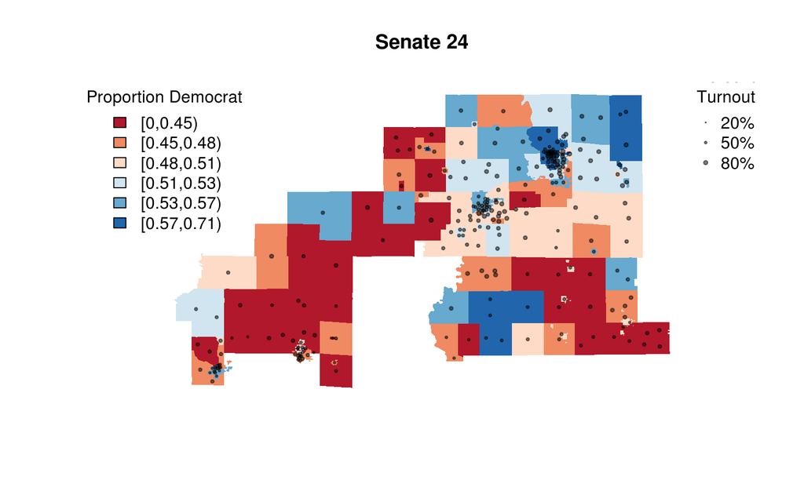

## Vector Data Modeling

```r
library(spdep)
wards@data$SEN_PERC_DEM = with(wards@data, SEN_DEM/SEN_TOT)
wards@data$SEN_PERC_TURN = with(wards@data, SEN_TOT/PERSONS1)
wards@data$CON_PERC_DEM = with(wards@data, CON_DEM/CON_TOT)
wards@data$PRES_PERC_DEM = with(wards@data, PRES_DE/PRES_TO)

### Remove NaN's created from x/0
wards = subset(wards, !is.nan(wards@data$SEN_PERC_DEM))
### Create the neighborhood structure,
###     which defines the error structure
###     for the spatial regression
neighborhood_binary = poly2nb(wards)
list_of_weights = nb2listw(neighborhood_binary, zero.policy=T)
### Run Moran's i to see if there is a spatial component to % dem
moran.test(wards@data$SEN_PERC_DEM, list_of_weights, alternative="two.sided")
```

```
##
##  Moran I test under randomisation
##
## data:  wards@data$SEN_PERC_DEM
## weights: list_of_weights
##
## Moran I statistic standard deviate = 15.295, p-value < 2.2e-16
## alternative hypothesis: two.sided
## sample estimates:
## Moran I statistic       Expectation          Variance
##       0.567975167      -0.003623188       0.001396579
```

```r
### Run spatial regression
spat_lin_reg = spautolm(
    SEN_PERC_DEM ~ WHITE + BLACK + PRES_PERC_DEM + CON_PERC_DEM,
    data=wards,
    family="SAR",
    listw=list_of_weights)
```